# Trabajo Final Black Friday

Javier Ortiz Montenegro

11 de enero de 2019

Se cargan las diversas librerías necesarias.

```r
library(tidyverse)
library(webshot)
library(GGally)
library(recommenderlab)
library(caret)
library(reticulate)
library(shiny)
```

Lo primero a la hora de tratar los datos será su carga, comprobación, limpieza de NAs, y transformación de las variables a formatos optimos.

```r
bf.df = read_csv("BlackFriday.csv") #Se cargan directamente los datos en una tibble
bf.df %>% summary() #Se comprueban los datos que contiene para saber como tratarlos
```

```
##     User_ID         Product_ID           Gender
##  Min.   :1000001   Length:537577      Length:537577
##  1st Qu.:1001495   Class :character   Class :character
##  Median :1003031   Mode  :character   Mode  :character
##  Mean   :1002992
##  3rd Qu.:1004417
##  Max.   :1006040
##
##      Age              Occupation     City_Category
##  Length:537577      Min.   : 0.000   Length:537577
##  Class :character   1st Qu.: 2.000   Class :character
##  Mode  :character   Median : 7.000   Mode  :character
##                     Mean   : 8.083
##                     3rd Qu.:14.000
##                     Max.   :20.000
##
##  Stay_In_Current_City_Years Marital_Status   Product_Category_1
##  Length:537577              Min.   :0.0000   Min.   : 1.000
##  Class :character           1st Qu.:0.0000   1st Qu.: 1.000
##  Mode  :character           Median :0.0000   Median : 5.000
##                             Mean   :0.4088   Mean   : 5.296
##                             3rd Qu.:1.0000   3rd Qu.: 8.000
##                             Max.   :1.0000   Max.   :18.000
##
##  Product_Category_2 Product_Category_3    Purchase
##  Min.   : 2.00      Min.   : 3.0       Min.   :  185
##  1st Qu.: 5.00      1st Qu.: 9.0       1st Qu.: 5866
##  Median : 9.00      Median :14.0       Median : 8062
##  Mean   : 9.84      Mean   :12.7       Mean   : 9334
##  3rd Qu.:15.00      3rd Qu.:16.0       3rd Qu.:12073
##  Max.   :18.00      Max.   :18.0       Max.   :23961
##  NA's   :166986     NA's   :373299
```

```r
bf.df %>% str()
```

```
## Classes 'spec_tbl_df', 'tbl_df', 'tbl' and 'data.frame': 537577 obs. of  12 variables:
##  $ User_ID                   : num  1e+06 1e+06 1e+06 1e+06 1e+06 ...
##  $ Product_ID                : chr  "P00069042" "P00248942" "P00087842" "P00085442" ...
##  $ Gender                    : chr  "F" "F" "F" "F" ...
##  $ Age                       : chr  "0-17" "0-17" "0-17" "0-17" ...
##  $ Occupation                : num  10 10 10 10 16 15 7 7 7 20 ...
##  $ City_Category             : chr  "A" "A" "A" "A" ...
##  $ Stay_In_Current_City_Years: chr  "2" "2" "2" "2" ...
##  $ Marital_Status            : num  0 0 0 0 0 0 1 1 1 1 ...
##  $ Product_Category_1        : num  3 1 12 12 8 1 1 1 1 8 ...
##  $ Product_Category_2        : num  NA 6 NA 14 NA 2 8 15 16 NA ...
##  $ Product_Category_3        : num  NA 14 NA NA NA NA 17 NA NA NA ...
##  $ Purchase                  : num  8370 15200 1422 1057 7969 ...
##  - attr(*, "spec")=
##   .. cols(
##   ..   User_ID = col_double(),
##   ..   Product_ID = col_character(),
##   ..   Gender = col_character(),
##   ..   Age = col_character(),
##   ..   Occupation = col_double(),
##   ..   City_Category = col_character(),
##   ..   Stay_In_Current_City_Years = col_character(),
##   ..   Marital_Status = col_double(),
##   ..   Product_Category_1 = col_double(),
##   ..   Product_Category_2 = col_double(),
##   ..   Product_Category_3 = col_double(),
##   ..   Purchase = col_double()
##   .. )
```

```r
bf.df %>% head()
```

```
## # A tibble: 6 x 12
##   User_ID Product_ID Gender Age   Occupation City_Category Stay_In_Current~
##     <dbl> <chr>      <chr>  <chr>      <dbl> <chr>         <chr>
## 1 1000001 P00069042  F      0-17          10 A             2
## 2 1000001 P00248942  F      0-17          10 A             2
## 3 1000001 P00087842  F      0-17          10 A             2
## 4 1000001 P00085442  F      0-17          10 A             2
## 5 1000002 P00285442  M      55+           16 C             4+
## 6 1000003 P00193542  M      26-35         15 A             3
## # ... with 5 more variables: Marital_Status <dbl>,
## #   Product_Category_1 <dbl>, Product_Category_2 <dbl>,
## #   Product_Category_3 <dbl>, Purchase <dbl>
```

```r
bf.df %>% tail()
```

```
## # A tibble: 6 x 12
##   User_ID Product_ID Gender Age   Occupation City_Category Stay_In_Current~
##     <dbl> <chr>      <chr>  <chr>      <dbl> <chr>         <chr>
## 1 1004737 P00221442  M      36-45         16 C             1
## 2 1004737 P00193542  M      36-45         16 C             1
## 3 1004737 P00111142  M      36-45         16 C             1
## 4 1004737 P00345942  M      36-45         16 C             1
## 5 1004737 P00285842  M      36-45         16 C             1
## 6 1004737 P00118242  M      36-45         16 C             1
## # ... with 5 more variables: Marital_Status <dbl>,
## #   Product_Category_1 <dbl>, Product_Category_2 <dbl>,
## #   Product_Category_3 <dbl>, Purchase <dbl>
```

```r
bf.df = mutate(bf.df[,-c(10:11)]) %>% na.omit %>% droplevels() #Se eliminan NAs (Especialmente concentrados en las columnas Product_Category 2 y 3)
bf.df = bf.df[!duplicated(bf.df),] #Se eliminan duplicados en caso de haberlos
bf.df$User_ID = bf.df$User_ID - 1000000 #Se convierten User_ID en números del 1 al 6040
bf.df$User_ID = as.factor(bf.df$User_ID) #Se transforman a factor los datos que se considera oportuno
bf.df$Product_ID = as.factor(bf.df$Product_ID)
bf.df$Gender = as.factor(bf.df$Gender)
bf.df$Age = as.factor(bf.df$Age)
bf.df$City_Category = as.factor(bf.df$City_Category)
bf.df$Marital_Status = as.factor(bf.df$Marital_Status)
bf.df$Stay_In_Current_City_Years = as.factor(bf.df$Stay_In_Current_City_Years)
bf.df$Product_Category_1 = as.factor(bf.df$Product_Category_1)
bf.df$Occupation = as.factor(bf.df$Occupation)
bf.df %>% summary() #De nuevo se comprueban los datos para confirmar que ya estén "limpios"
```

```
##     User_ID           Product_ID     Gender        Age
##  1680   :  1025   P00265242:  1858   F:132197   0-17 : 14707
##  4277   :   978   P00110742:  1591   M:405380   18-25: 97634
##  1941   :   898   P00025442:  1586              26-35:214690
##  1181   :   861   P00112142:  1539              36-45:107499
##  889    :   822   P00057642:  1430              46-50: 44526
##  3618   :   766   P00184942:  1424              51-55: 37618
##  (Other):532227   (Other)  :528149              55+  : 20903
##    Occupation     City_Category Stay_In_Current_City_Years Marital_Status
##  4      : 70862   A:144638      0 : 72725                  0:317817
##  0      : 68120   B:226493      1 :189192                  1:219760
##  7      : 57806   C:166446      2 : 99459
##  1      : 45971                 3 : 93312
##  17     : 39090                 4+: 82889
##  20     : 32910
##  (Other):222818
##  Product_Category_1    Purchase
##  5      :148592     Min.   :  185
##  1      :138353     1st Qu.: 5866
##  8      :112132     Median : 8062
##  11     : 23960     Mean   : 9334
##  2      : 23499     3rd Qu.:12073
##  6      : 20164     Max.   :23961
##  (Other): 70877
```

```r
bf.df %>% str()
```

```
## Classes 'tbl_df', 'tbl' and 'data.frame':    537577 obs. of  10 variables:
##  $ User_ID                   : Factor w/ 5891 levels "1","2","3","4",..: 1 1 1 1 2 3 4 4 4 5 ...
##  $ Product_ID                : Factor w/ 3623 levels "P00000142","P00000242",..: 671 2375 851 827 2733 1830 1744 3319 3597 2630 ...
##  $ Gender                    : Factor w/ 2 levels "F","M": 1 1 1 1 2 2 2 2 2 2 ...
##  $ Age                       : Factor w/ 7 levels "0-17","18-25",..: 1 1 1 1 7 3 5 5 5 3 ...
##  $ Occupation                : Factor w/ 21 levels "0","1","2","3",..: 11 11 11 11 17 16 8 8 8 21 ...
##  $ City_Category             : Factor w/ 3 levels "A","B","C": 1 1 1 1 3 1 2 2 2 1 ...
##  $ Stay_In_Current_City_Years: Factor w/ 5 levels "0","1","2","3",..: 3 3 3 3 5 4 3 3 3 2 ...
##  $ Marital_Status            : Factor w/ 2 levels "0","1": 1 1 1 1 1 1 2 2 2 2 ...
##  $ Product_Category_1        : Factor w/ 18 levels "1","2","3","4",..: 3 1 12 12 8 1 1 1 1 8 ...
##  $ Purchase                  : num  8370 15200 1422 1057 7969 ...
```

Se integra una gráfica dinámica mediante shiny para realizar los cruces basicos del gasto y orientar hacia estudios interesantes de los datos.

```r
#En mi pc tarda un poco en cargar los gráficos. Espero que con un procesador más potente sea más fluido.
if (interactive()) {
  runGitHub("Javomgo/Black-Friday", port=2019)
}
#Es necesario lanzar primero el shiny y después hacer el knit para que aparezca en el html.
#He intentado subirlo a shinyapps.io para tenerlo activo y evitar esa necesidad, pero la versión gratuita no tiene memoria suficiente para soportarlo.
knitr::include_app("http://127.0.0.1:2019", height = 750)
```

[interactive chart not shown]

Es digno de mención el hecho de que la categoría de producto con mayor gasto es la 1 y sin embargo en unidades este puesto pertenece a la categoría 5 (Como se puede comprobar al realizar el summary).

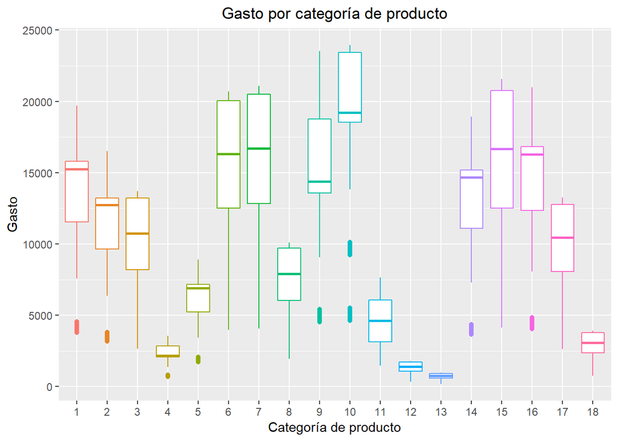

```r
bf.df %>%  ggplot(aes(x = Product_Category_1, y = Purchase, color = Product_Category_1)) + geom_boxplot(show.legend = F) + xlab("Categoría de producto") + ylab("Gasto") + ggtitle("Gasto por categoría de producto") + theme(plot.title = element_text(hjust = 0.5))
```

En este boxplot se puede comprobar como las categorías que más han vendido en el black friday no son productos que pertenezcan a una categoría de lujo (La categoría 1 es más cara que la 5 y la 8, pero aún así sería discutible catalogar dicha categoría como articulos de lujo).

Compras hombres vs compra mujeres por categorías,

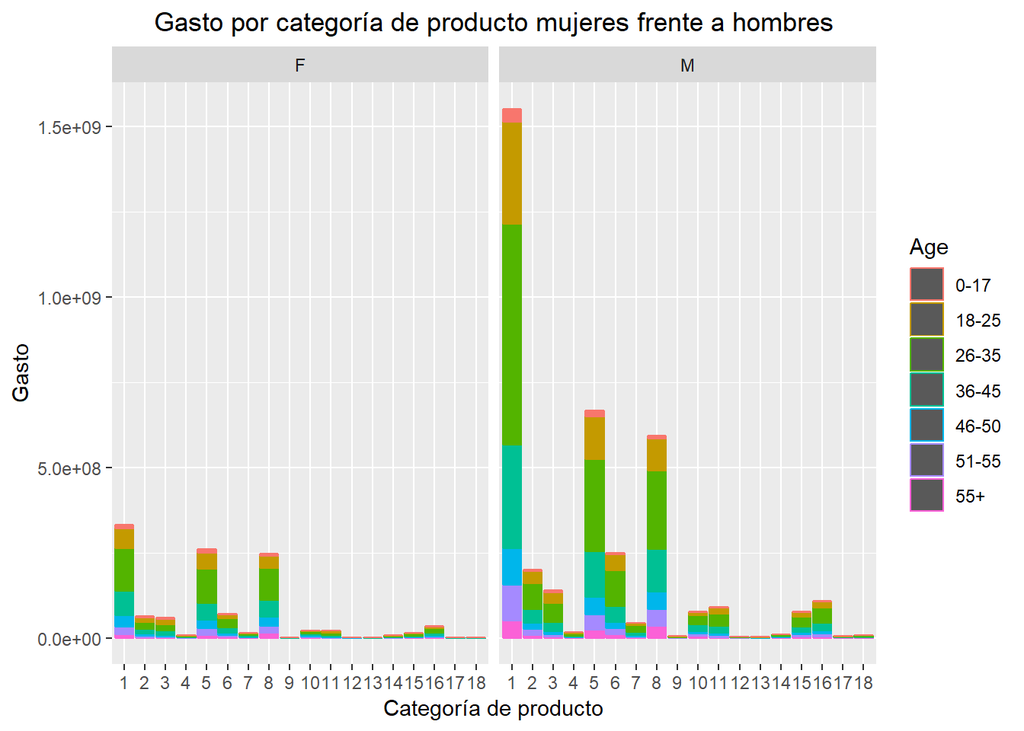

```r
bf.df %>% ggplot(aes(x = Product_Category_1, y = Purchase, color = Age)) + geom_bar(show.legend = T, stat = "identity") + xlab("Categoría de producto") + ylab("Gasto") + ggtitle("Gasto por categoría de producto mujeres frente a hombres") + facet_wrap(~ Gender) + theme(plot.title = element_text(hjust = 0.5))
```

Como se pude comprobar practicamente todas las categorías tienen un gasto mayor cuando el genero es hombre, no obstante, el mayor aumento con diferencia es en la categoría producto 1, lo cual hace pensar que es una categoría especialmente atractiva para el cliente masculino.

El siguiente gráfico es una combinación de distintos cruces entre variables, los colores corresponden de la siguiente manera: Rojo = Mujer, Azul = hombre.

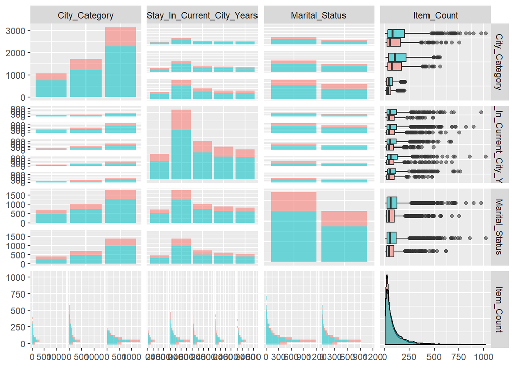

```r
bfcant.df = bf.df %>% group_by(User_ID) %>% summarise(Gender = Gender[1],Age = Age[1],Occupation = Occupation[1], City_Category = City_Category[1], Stay_In_Current_City_Years = Stay_In_Current_City_Years[1], Marital_Status = Marital_Status[1], Item_Count = n())
#Se juntan los compradores para no desvirtuar los resultados de las próximas graficas al cruzar variables factor entre ellas ya que de no ser así se contabilizarían de forma multiple los usuarios con más de una compra.
ggpairs(bfcant.df[,c(5:8)], cardinality_threshold = 21, aes(color = bfcant.df$Gender, alpha = 0.5))
```

Las gráficas no muestran mucha información nueva, únicamente comentar el hecho de que si observamos la cantidad de compradores la categoría ciudad con más compradores es la C con mucha diferencia siendo la B la que tiene mayor gasto total.

Una vez comprobados los datos y tras realizar un análisis por encima de los mismos se puede confirmar que si una empresa decidiera entrar en el mercado la recomendación sería fabricar productos de la categoría 1, y tener una inversión en marketing especialmente dedicada a hombres entre 26 y 35 años, soltero, que resida desde hace un año en una ciudad de categoría B, y que se dedique a la profesión 0, 4 ó 7.

Para profundizar más podría realizar una predicción de las ventas en caso de pretender vender unicamente a ese objetivo y dedicarse a la categoría de producto 1, o realizar una clasificación de la edad de un comprador según el resto de variables, pero este tipo de modelos ya los he realizado en otras asignaturas. Por lo tanto me decantaré por un sistema de recomendación, modelo que aún no he trabajado y que también tiene sentido con estos datos.

Se comienza con el tratamiento de los datos convirtiendo el data frame original en una matriz binaria que recoja el ID del usuario y los productos comprados. De esta manera se podrá realizar un clustering jerárquico y su representación por medio de un dendrograma para ver la agrupación de los usuarios, posteriormente se utilizará el paquete recommenderlab para realizar el modelo y predicción de las recomendaciones.

```r
#Se transforma el data frame pasando cada factor de la columna Product_ID a una variable propia con el ID del producto y de esta manera transformar el data frame en una matriz binaria con 0 en caso de no haber comprado el producto y 1 en caso de si haberlo comprado.
bfcant = bf.df %>%
  gather(observation, Val, Product_ID) %>%
  group_by(User_ID,observation, Val) %>%
  summarise(n= n()) %>%
  ungroup() %>%
  spread(Val, n, fill=0)

#Se eliminan las columnas 1 y 2 que corresponden a User_ID (ya recogido en el índice) y a una columna que recoge "Product_ID" ya que es el nombre de la columna original.
#De la misma manera únicamente seleccionamos los usuarios con más de 40 compras y los productos adquiridos más de 80 veces, eliminando así todos aquellos usuarios y productos no interesantes para realizar recomendaciones.
bfcant = bfcant[,-c(1,2)]
bfcant = bfcant[rowSums(bfcant) > 40,
                colSums(bfcant) > 80]


#Por ultimo se transforma el data frame en una binaryRatingMatrix para poder trabajar y entrenar el modelo.
bf.bin = data.matrix(bfcant)
bf.bin = as(bf.bin, "binaryRatingMatrix")
```

Una vez tratados los datos se realizará el clustering jerarquico y su representación mediante un drendrograma mediante código de python.

```python
import os
os.environ['QT_QPA_PLATFORM_PLUGIN_PATH'] = 'C:/Users/Javo/Anaconda3/Library/plugins/platforms' #Me saltaba error sin indicar manualmente el directorio de "platforms" de conda.
import matplotlib.pyplot as plt
from scipy.cluster.hierarchy import dendrogram, linkage
import pandas as pd
clus = linkage(r.bfcant, "ward")
plt.figure(figsize = (60,40))
plt.title("Dendrograma jerarquico del clustering de usuarios truncado", fontsize = 60)
plt.xlabel("ID de los compradores", fontsize = 60)
plt.ylabel("Distancia", fontsize = 60)
plt.yticks(size = 50)
dendrogram(clus, leaf_rotation = 90., leaf_font_size = 50.0, truncate_mode = "lastp", p = 40, color_threshold = 40, show_leaf_counts = True, show_contracted = True)
plt.show()
```

[figure not shown]

A una distancia de 40 se generan 10 clusters, aunque como se puede comprobar la cantidad de usuarios en algunos de estos clusters es muy elevada por lo que se pordía dividir en una mayor cantidad. Sin embargo, la realización de este dendrograma era únicamente para comprobar, de manera visual, de que manera se unian los usuarios. Por lo tanto, no se profundizará más en la busqueda del K óptimo para realizar una separación por cluster perfecta, ya que el objetivo es realizar un sistema de recomendación que sea funcional en una hipotética tienda online.

Dicho esto, se procede al entrenamiento y predicción del modelo de recomendación, inicialmente se realizará una evaluación mediante validación cruzada para, de esta manera, seleccionar el mejor modelo de recomendación. Una vez seleccionado el modelo que mejor se adapte a las necesidades se construirá un modelo hibrido para que un porcentaje de las recomendaciones salgan de la “zona de confort” del usuario.

```r
set.seed(2019)

#Se usa validación cruzada para validar las recomendaciones.
eval_sets = evaluationScheme(data = bf.bin,
                             method = "cross-validation",
                             k = 5,
                             given = 20)

#Los modelos a comparar son basados en usuarios, basados en items (mediante distintos metodos), y por ultimo un modelo aleatorio.
modelos = list(IBCF.cos = list(name = "IBCF", params = list(method = "cosine")),
               IBCF.cor = list(name = "IBCF", params = list(method = "pearson")),
               IBCF.jac = list(name = "IBCF", params = list(method = "Jaccard")),
               UBCF.cos = list(name = "UBCF", params = list(method = "cosine")),
               UBCF.cor = list(name = "UBCF", params = list(method = "pearson")),
               UBCF.jac = list(name = "UBCF", params = list(method = "Jaccard")),
               random = list(name = "RANDOM", params = NULL))

resul = evaluate(x = eval_sets,
                 method = modelos,
                 n = c(1:7, seq(10,100,10)))
```

Se comprueban los resultados de la validación cruzada mediante gráficos.

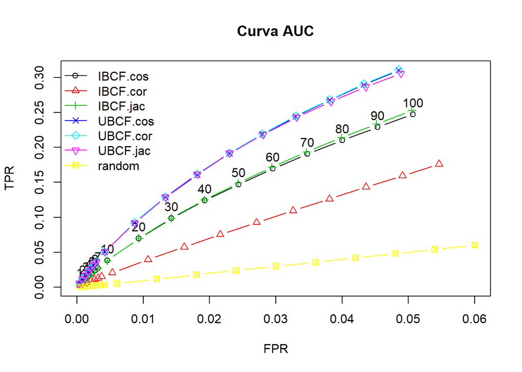

```r
plot(resul, annotate = 1, legend = "topleft") + title("Curva AUC")
```

Este primer gráfico muestra el ratio de verdaderos positivos, en el eje de ordenadas, frente al ratio de falsos positivos, en el eje de abscisas. Se puede extraer de dicho gráfico que los modelos basados en usuarios tienen un mejor ratio de verdaderos positivos frente a falsos.

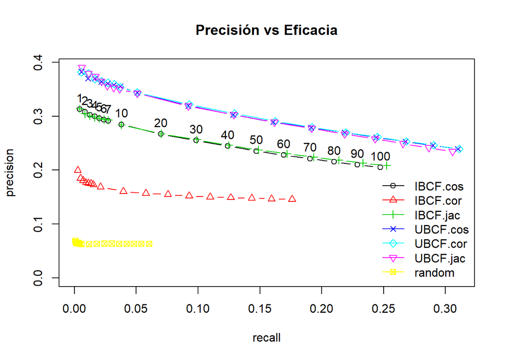

```r
plot(resul, "prec/rec", annotate = 1, legend = "bottomright") + title("Precisión vs Eficacia")
```

En este caso, el gráfico cruza precisión contra eficacia se puede observar como el metodo de Jaccard produce mejores resultados con pocas recomendaciones y como el la intención es que se recomienden unos 10 productos dicho metodo es el apropiado.

Se procede a una evaluación individual del modelo orientado a usuarios con Jaccard en mayor profundidad.

```r
res.jac = evaluate(x = eval_sets,
                 method = "UBCF", parameter = list(method = "Jaccard"),
                 n = seq(10,100,10))
getConfusionMatrix(res.jac)[[1]]
```

[output not shown]

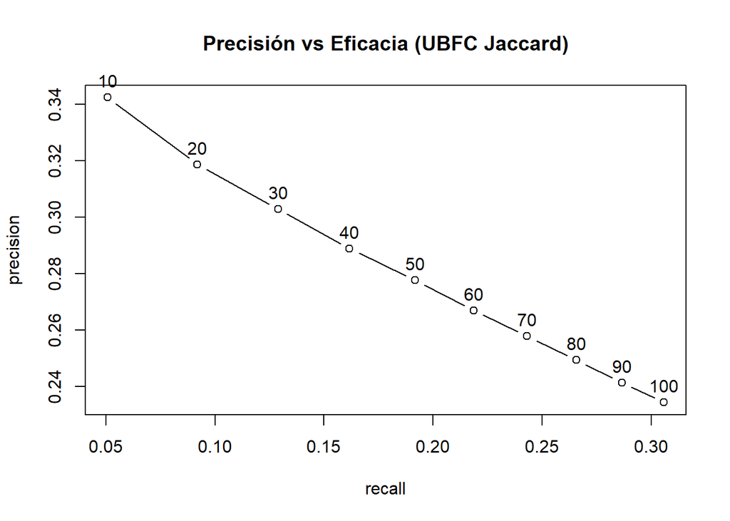

```r
plot(res.jac, "prec/rec", annotate = T, main = "Precisión vs Eficacia (UBFC Jaccard)")
```

```r
#Se separan los datos en dos grupos, uno de entrenamiento y otro de prueba.
sep = sample(x= c(T, F),
             size = nrow(bf.bin),
             replace = T,
             prob = c(0.8, 0.2))

train = bf.bin[sep,]
test = bf.bin[!sep,]

#Se entrena el modelo con el subconjunto de entrenamiento.
recom_hibrida = HybridRecommender(
  Recommender(train, method = "UBCF", parameter = list(method = "Jaccard")),
  Recommender(train, method = "RANDOM"),
  weights = c(0.85, 0.15))

#Se procede a la predicción con el subconjunto de prueba.
pred = predict(object = recom_hibrida, newdata = test, n = 12)
rec.matrix = sapply(pred@items, function(x){
                            colnames(bf.bin[,x])
  })

#Se muestran 12 recomendaciones para los 5 primeros usuarios, de esta manera comprobamos que funcione correctamente.
rec.matrix[,1:5]
```

```
##       1           3           6           13          15
##  [1,] "P00046742" "P00117442" "P00183642" "P00112142" "P00145042"
##  [2,] "P00237542" "P00031042" "P00058042" "P00251342" "P00242742"
##  [3,] "P00073842" "P00085942" "P00057542" "P00057942" "P00000142"
##  [4,] "P0097242"  "P00034742" "P00120042" "P00138542" "P00112142"
##  [5,] "P00037142" "P00102642" "P00303242" "P00129642" "P00102642"
##  [6,] "P00110942" "P00010742" "P00243942" "P00057642" "P00034842"
##  [7,] "P00145042" "P00109542" "P00237542" "P00127942" "P00199442"
##  [8,] "P00036842" "P00157542" "P00034742" "P00178942" "P00003442"
##  [9,] "P00147742" "P00051442" "P00059442" "P00112642" "P00258742"
## [10,] "P00182142" "P00350942" "P00025442" "P00282042" "P00271142"
## [11,] "P00157642" "P00289942" "P00110942" "P00260042" "P00117442"
## [12,] "P00156442" "P00115642" "P00102642" "P00114942" "P00270842"
```